# Analyse le fichier mergé

# Par age

## Adultes (18 à 75 ans)

```r
d3a <- d3[d3$AGE > 17 & d3$AGE < 76,]
n.adl <- nrow(d3a)

# table fréquence
s.type.adl <- table(d3a$TYPE_URGENCES)
s.type.adl
```

```
##
##      Autre recours Médico-chirurgical      Psychiatrique
##               5375              80448               4532
##      Toxicologique    Traumatologique
##               3546              53216
```

```r
# table des proportion
p.type.adl <- round(prop.table(s.type.adl) * 100, 2)
p.type.adl
```

```
##
##      Autre recours Médico-chirurgical      Psychiatrique
##               3.65              54.68               3.08
##      Toxicologique    Traumatologique
##               2.41              36.17
```

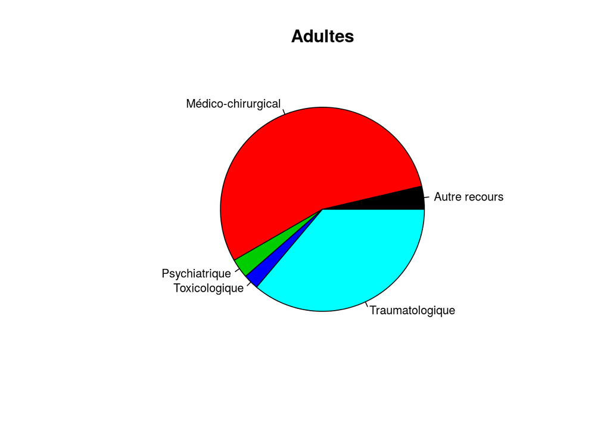

```r
pie(s.type.adl, main = "Adultes", cex=0.8, col = palette(heat.colors(6)))
```

```r
taba <- tab1(d3a$TYPE_URGENCES, sort.group = "decreasing", bar.values = "percent", cex.names = 0.8, main = paste0("Médico-chirurgical adulte (N = ", n.adl, ")"), missing = FALSE)
```

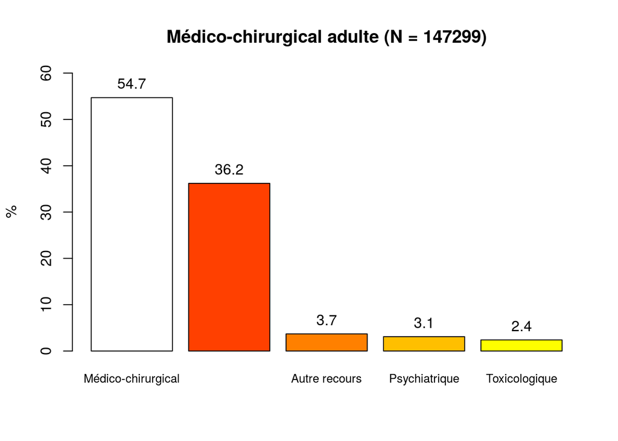

## Pédiatrie (age < 18 ans)

```r
d3p <- d3[d3$AGE < 18,]
n.ped<- nrow(d3p)

s.type.ped <- table(d3p$TYPE_URGENCES)
sort(s.type.ped, decreasing = TRUE)
```

```
##
## Médico-chirurgical    Traumatologique      Autre recours
##              45173              37842               2237
##      Psychiatrique      Toxicologique
##                768                471
```

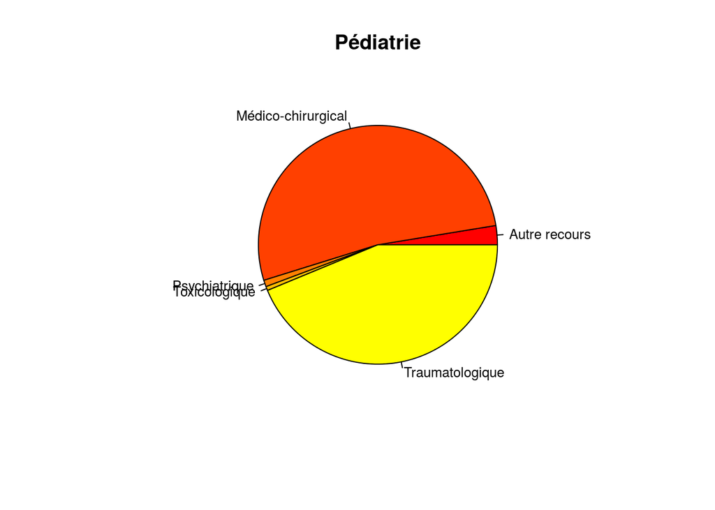

```r
pie(s.type.ped, main = "Pédiatrie", cex=0.8, col = palette(heat.colors(6)))
```

```r
tabp <- tab1(d3p$TYPE_URGENCES, sort.group = "decreasing", bar.values = "percent", cex.names = 0.8, main = paste0("Médico-chirurgical pédiatrique (N = ", n.ped, ")"), missing = FALSE)
```

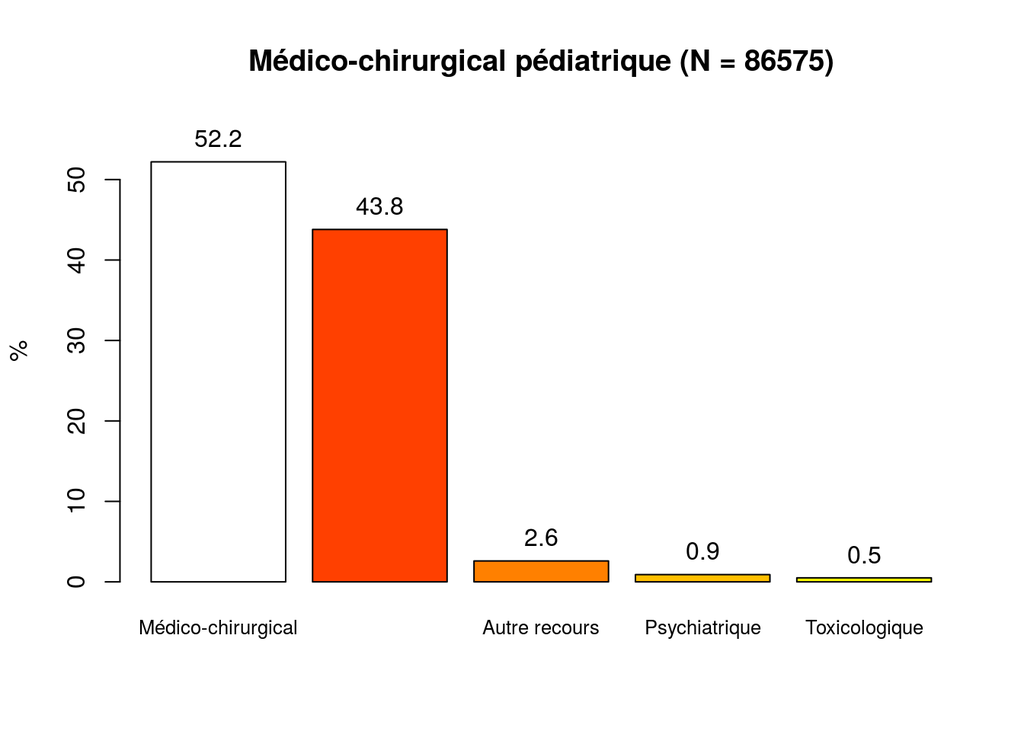

## Gériatrie (age > 75 ans)

```r
d3g <- d3[d3$AGE > 75,]
n.ger <- nrow(d3g)

s.type.ger <- table(d3g$TYPE_URGENCES)
sort(s.type.ger, decreasing = TRUE)
```

```
##
## Médico-chirurgical    Traumatologique      Autre recours
##              22198               8500                533
##      Psychiatrique      Toxicologique
##                376                163
```

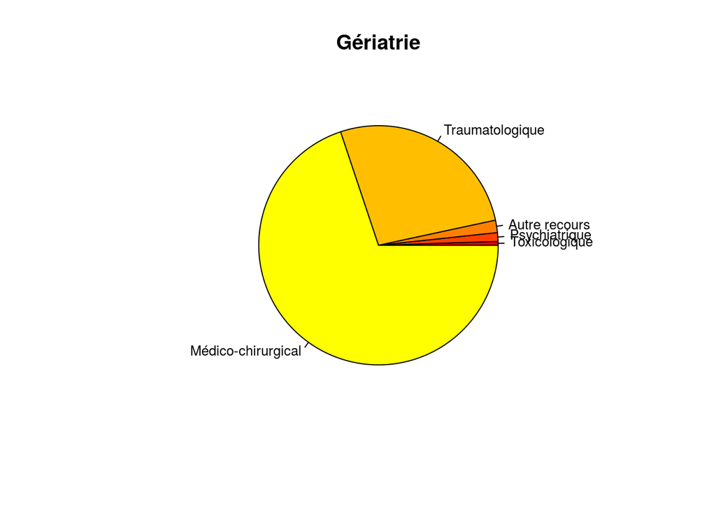

```r
pie(sort(s.type.ger), main = "Gériatrie", cex=0.8, col = palette(heat.colors(6)))
```

```r
tabp <- tab1(d3g$TYPE_URGENCES, sort.group = "decreasing", bar.values = "percent", cex.names = 0.8, main = paste0("Médico-chirurgical gériatrique (N = ", n.ger, ")"), missing = FALSE)
```

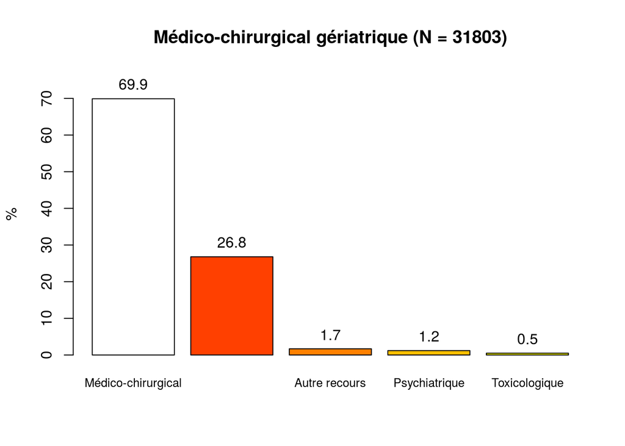

## Synthèse

```r
# table de regroupement
t.type <- rbind(s.type.adl, s.type.ped, s.type.ger)
t.type
```

```
##            Autre recours Médico-chirurgical Psychiatrique Toxicologique
## s.type.adl          5375              80448          4532          3546
## s.type.ped          2237              45173           768           471
## s.type.ger           533              22198           376           163
##            Traumatologique
## s.type.adl           53216
## s.type.ped           37842
## s.type.ger            8500
```

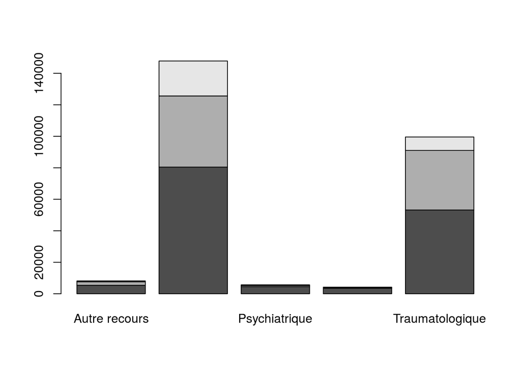

```r
barplot(t.type)
```

```r
# en pourcentages
p.type <- round(prop.table(t.type, margin = 1)*100, 2)
p.type
```

```
##            Autre recours Médico-chirurgical Psychiatrique Toxicologique
## s.type.adl          3.65              54.68          3.08          2.41
## s.type.ped          2.59              52.23          0.89          0.54
## s.type.ger          1.68              69.87          1.18          0.51
##            Traumatologique
## s.type.adl           36.17
## s.type.ped           43.75
## s.type.ger           26.75
```

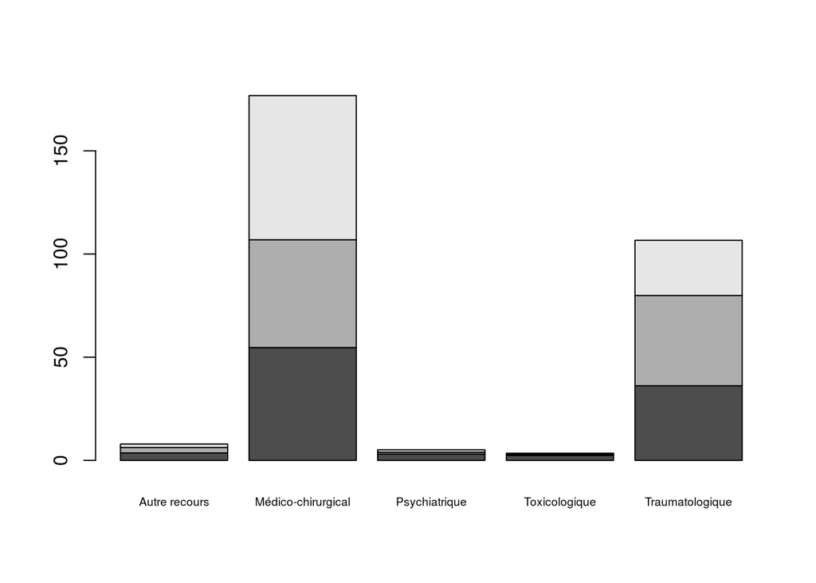

```r
color <- c("red", "green", "yellow")
barplot(p.type, cex.names = 0.6)
```

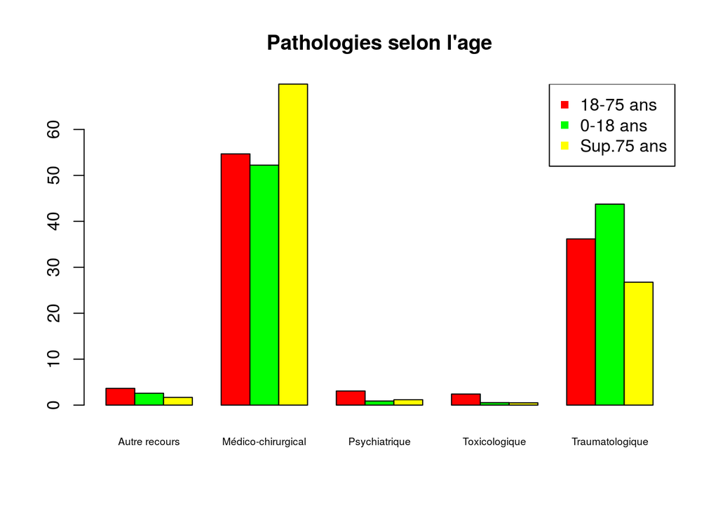

```r
barplot(p.type, cex.names = 0.6, beside = TRUE, col = color, main = "Pathologies selon l'age")
legend("topright", legend = c("18-75 ans","0-18 ans","Sup.75 ans"), col = color, pch = 15)
```

# Par chapitre

## Adultes

### Pathologie médico-chirurgicale

```r
medic.adl <- d3a[d3a$TYPE_URGENCES == "Médico-chirurgical",]
n.medic.adl <- nrow(medic.adl)
s.medic.adl <- table(factor(medic.adl$CHAPITRE))
p.medic.adl <- round(prop.table(s.medic.adl)*100, 2)
sort(p.medic.adl, decreasing = TRUE)
```

```
##
##            Douleurs de membre, rhumatologie, orthopédie, SNP
##                                                        18.61
##                 Douleurs abdominales, pathologies digestives
##                                                        17.36
##            ORL, ophtalmo, stomato et carrefour aéro-digestif
##                                                         9.66
##               Douleurs pelviennes, pathologies uro-génitales
##                                                         9.30
##         Douleurs thoraciques, pathologies cardio-vasculaires
##                                                         8.61
##                Céphalées, pathologies neurologiques hors SNP
##                                                         7.81
##          Dermato-allergologie et atteintes cutanéo-muqueuses
##                                                         7.12
##                        Signes généraux et autres pathologies
##                                                         6.58
## Malaises, lipothymies, syncopes, étourdissements et vertiges
##                                                         6.27
##        Dyspnées, pathologies des voies aériennes inférieures
##                                                         6.20
##                             Fièvre et infectiologie générale
##                                                         2.48
```

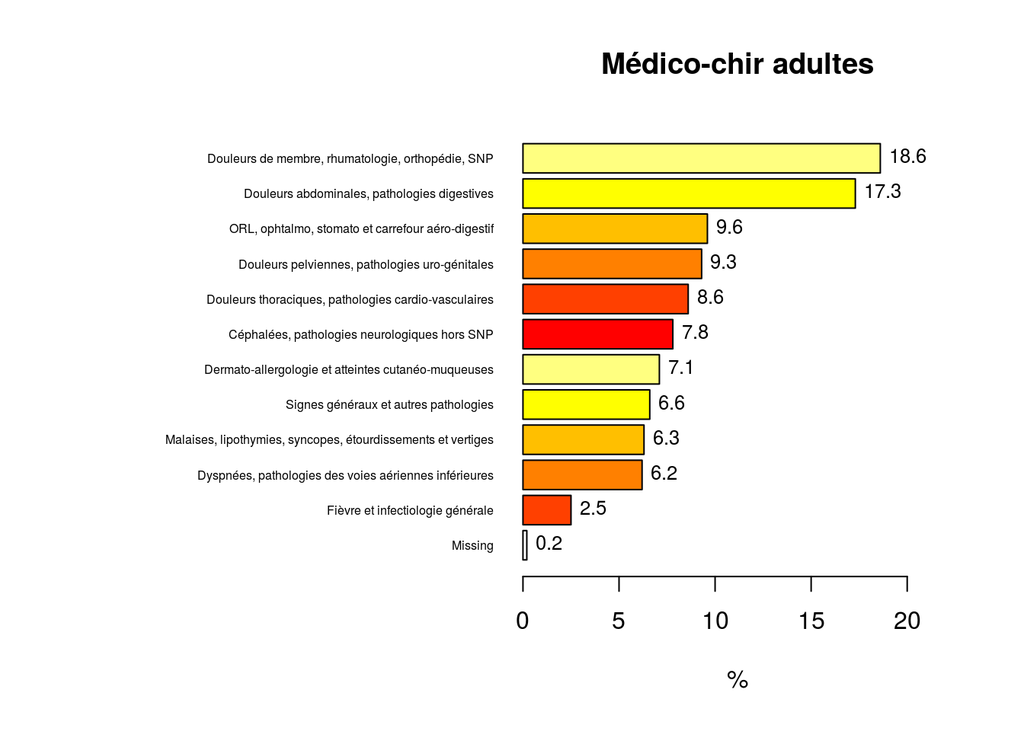

```
## factor(medic.adl$CHAPITRE) :
##                                                              Frequency
## Douleurs de membre, rhumatologie, orthopédie, SNP                14972
## Douleurs abdominales, pathologies digestives                     13964
## ORL, ophtalmo, stomato et carrefour aéro-digestif                 7775
## Douleurs pelviennes, pathologies uro-génitales                    7480
## Douleurs thoraciques, pathologies cardio-vasculaires              6927
## Céphalées, pathologies neurologiques hors SNP                     6286
## Dermato-allergologie et atteintes cutanéo-muqueuses               5727
## Signes généraux et autres pathologies                             5293
## Malaises, lipothymies, syncopes, étourdissements et vertiges      5043
## Dyspnées, pathologies des voies aériennes inférieures             4984
## Fièvre et infectiologie générale                                  1997
## NA's                                                               182
##   Total                                                          80630
##                                                                %(NA+)
## Douleurs de membre, rhumatologie, orthopédie, SNP                18.6
## Douleurs abdominales, pathologies digestives                     17.3
## ORL, ophtalmo, stomato et carrefour aéro-digestif                 9.6
## Douleurs pelviennes, pathologies uro-génitales                    9.3
## Douleurs thoraciques, pathologies cardio-vasculaires              8.6
## Céphalées, pathologies neurologiques hors SNP                     7.8
## Dermato-allergologie et atteintes cutanéo-muqueuses               7.1
## Signes généraux et autres pathologies                             6.6
## Malaises, lipothymies, syncopes, étourdissements et vertiges      6.3
## Dyspnées, pathologies des voies aériennes inférieures             6.2
## Fièvre et infectiologie générale                                  2.5
## NA's                                                              0.2
##   Total                                                         100.0
##                                                                %(NA-)
## Douleurs de membre, rhumatologie, orthopédie, SNP                18.6
## Douleurs abdominales, pathologies digestives                     17.4
## ORL, ophtalmo, stomato et carrefour aéro-digestif                 9.7
## Douleurs pelviennes, pathologies uro-génitales                    9.3
## Douleurs thoraciques, pathologies cardio-vasculaires              8.6
## Céphalées, pathologies neurologiques hors SNP                     7.8
## Dermato-allergologie et atteintes cutanéo-muqueuses               7.1
## Signes généraux et autres pathologies                             6.6
## Malaises, lipothymies, syncopes, étourdissements et vertiges      6.3
## Dyspnées, pathologies des voies aériennes inférieures             6.2
## Fièvre et infectiologie générale                                  2.5
## NA's                                                              0.0
##   Total                                                         100.0
```

```r
tab1(factor(medic.adl$CHAPITRE), cex.names = 0.5, cex = 0.8, sort.group = "decreasing", main = "Médico-chir adultes", bar.values = "percent")
```

### Pathologie traumatique

```r
trauma.adl <- d3a[d3a$TYPE_URGENCES == "Traumatologique",]
n.trauma.adl <- nrow(trauma.adl)
s.trauma.adl <- table(factor(trauma.adl$CHAPITRE))
p.trauma.adl <- round(prop.table(s.trauma.adl)*100, 2)
sort(p.trauma.adl, decreasing = TRUE)
```

```
##
##      Traumatisme du membre supérieur      Traumatisme du membre inférieur
##                                37.75                                31.30
##     Traumatisme de la tête et du cou Traumatisme thoraco-abdomino-pelvien
##                                16.75                                 7.11
##  Traumatisme autre et sans précision
##                                 7.10
```

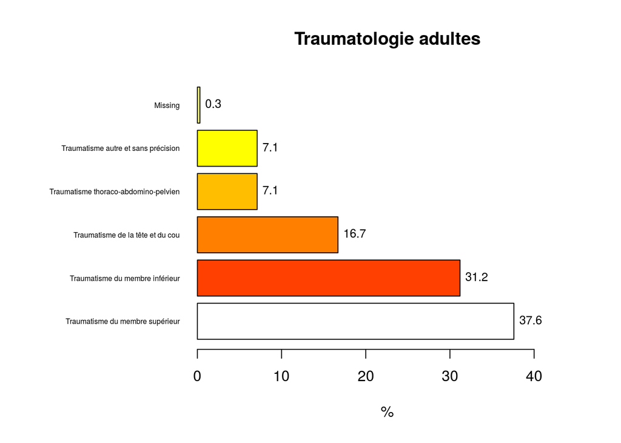

```
## factor(trauma.adl$CHAPITRE) :
##                                      Frequency   %(NA+)   %(NA-)
## Traumatisme du membre supérieur          20089     37.6     37.7
## Traumatisme du membre inférieur          16656     31.2     31.3
## Traumatisme de la tête et du cou          8912     16.7     16.7
## Traumatisme thoraco-abdomino-pelvien      3781      7.1      7.1
## Traumatisme autre et sans précision       3778      7.1      7.1
## NA's                                       182      0.3      0.0
##   Total                                  53398    100.0    100.0
```

```r
tab1(factor(trauma.adl$CHAPITRE), cex.names = 0.5, cex = 0.8, sort.group = "decreasing", main = "Traumatologie adultes", bar.values = "percent", horiz = TRUE)
```

## Enfants

### Pathologie médico-chirurgicale pédiatrique

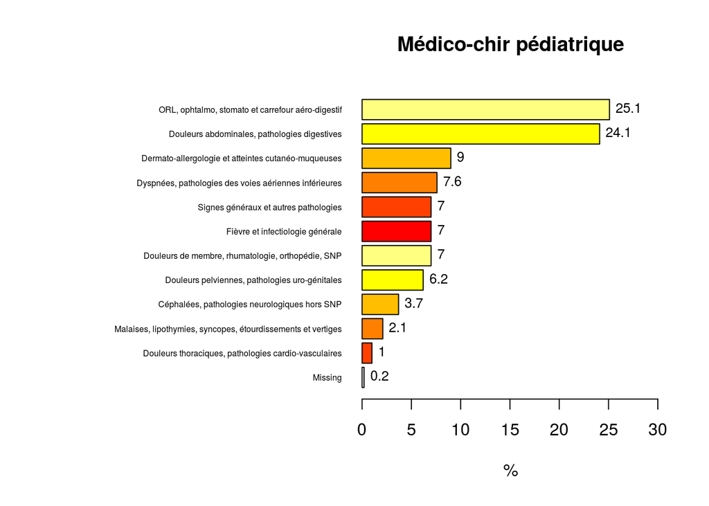

```
## f$data :
##                                                              Frequency
## ORL, ophtalmo, stomato et carrefour aéro-digestif                11343
## Douleurs abdominales, pathologies digestives                     10908
## Dermato-allergologie et atteintes cutanéo-muqueuses               4063
## Dyspnées, pathologies des voies aériennes inférieures             3422
## Fièvre et infectiologie générale                                  3185
## Douleurs de membre, rhumatologie, orthopédie, SNP                 3172
## Signes généraux et autres pathologies                             3172
## Douleurs pelviennes, pathologies uro-génitales                    2816
## Céphalées, pathologies neurologiques hors SNP                     1670
## Malaises, lipothymies, syncopes, étourdissements et vertiges       962
## Douleurs thoraciques, pathologies cardio-vasculaires               460
## NA's                                                                84
##   Total                                                          45257
##                                                                %(NA+)
## ORL, ophtalmo, stomato et carrefour aéro-digestif                25.1
## Douleurs abdominales, pathologies digestives                     24.1
## Dermato-allergologie et atteintes cutanéo-muqueuses               9.0
## Dyspnées, pathologies des voies aériennes inférieures             7.6
## Fièvre et infectiologie générale                                  7.0
## Douleurs de membre, rhumatologie, orthopédie, SNP                 7.0
## Signes généraux et autres pathologies                             7.0
## Douleurs pelviennes, pathologies uro-génitales                    6.2
## Céphalées, pathologies neurologiques hors SNP                     3.7
## Malaises, lipothymies, syncopes, étourdissements et vertiges      2.1
## Douleurs thoraciques, pathologies cardio-vasculaires              1.0
## NA's                                                              0.2
##   Total                                                         100.0
##                                                                %(NA-)
## ORL, ophtalmo, stomato et carrefour aéro-digestif                25.1
## Douleurs abdominales, pathologies digestives                     24.1
## Dermato-allergologie et atteintes cutanéo-muqueuses               9.0
## Dyspnées, pathologies des voies aériennes inférieures             7.6
## Fièvre et infectiologie générale                                  7.1
## Douleurs de membre, rhumatologie, orthopédie, SNP                 7.0
## Signes généraux et autres pathologies                             7.0
## Douleurs pelviennes, pathologies uro-génitales                    6.2
## Céphalées, pathologies neurologiques hors SNP                     3.7
## Malaises, lipothymies, syncopes, étourdissements et vertiges      2.1
## Douleurs thoraciques, pathologies cardio-vasculaires              1.0
## NA's                                                              0.0
##   Total                                                         100.0
```

```r
f <- groupe.pathologique(d3p, "medchir")
tab1(f$data, cex.names = 0.5, cex = 0.8, sort.group = "decreasing", main = "Médico-chir pédiatrique", bar.values = "percent")
```

### Pathologie traumatique pédiatrique

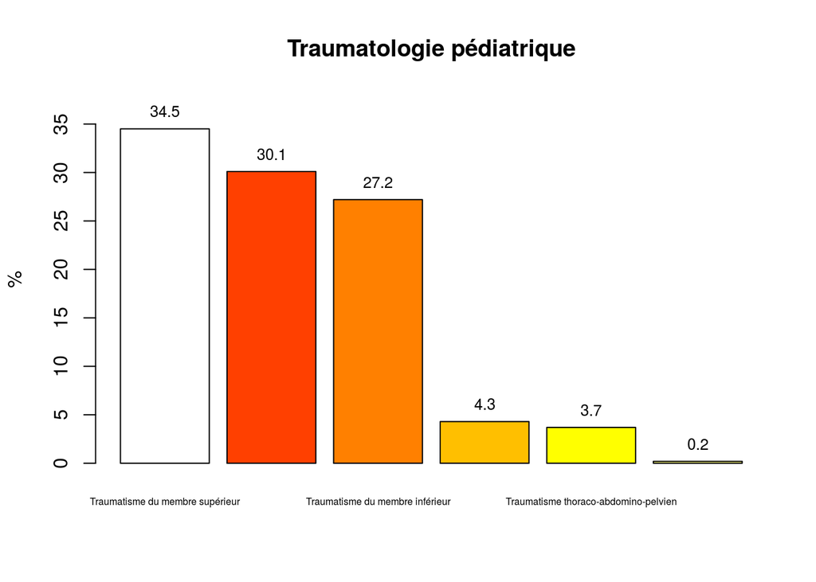

```
## f$data :
##                                      Frequency   %(NA+)   %(NA-)
## Traumatisme du membre supérieur          13072     34.5     34.5
## Traumatisme de la tête et du cou         11398     30.1     30.1
## Traumatisme du membre inférieur          10316     27.2     27.3
## Traumatisme autre et sans précision       1644      4.3      4.3
## Traumatisme thoraco-abdomino-pelvien      1412      3.7      3.7
## NA's                                        84      0.2      0.0
##   Total                                  37926    100.0    100.0
```

```r
f <- groupe.pathologique(d3p, "trau")
tab1(f$data, cex.names = 0.5, cex = 0.8, sort.group = "decreasing", main = "Traumatologie pédiatrique", bar.values = "percent")
```

## Gériatrie

### Pathologie médico-chirurgicale gériatrique

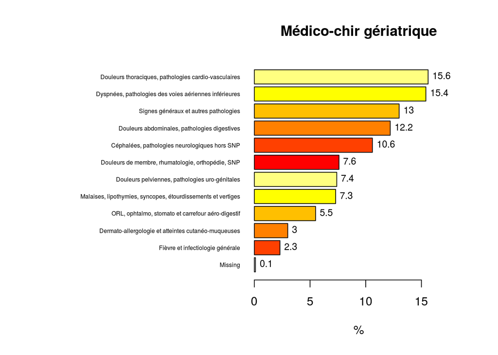

```
## f$data :
##                                                              Frequency
## Douleurs thoraciques, pathologies cardio-vasculaires              3471
## Dyspnées, pathologies des voies aériennes inférieures             3414
## Signes généraux et autres pathologies                             2898
## Douleurs abdominales, pathologies digestives                      2708
## Céphalées, pathologies neurologiques hors SNP                     2346
## Douleurs de membre, rhumatologie, orthopédie, SNP                 1690
## Douleurs pelviennes, pathologies uro-génitales                    1634
## Malaises, lipothymies, syncopes, étourdissements et vertiges      1627
## ORL, ophtalmo, stomato et carrefour aéro-digestif                 1216
## Dermato-allergologie et atteintes cutanéo-muqueuses                674
## Fièvre et infectiologie générale                                   520
## NA's                                                                33
##   Total                                                          22231
##                                                                %(NA+)
## Douleurs thoraciques, pathologies cardio-vasculaires             15.6
## Dyspnées, pathologies des voies aériennes inférieures            15.4
## Signes généraux et autres pathologies                            13.0
## Douleurs abdominales, pathologies digestives                     12.2
## Céphalées, pathologies neurologiques hors SNP                    10.6
## Douleurs de membre, rhumatologie, orthopédie, SNP                 7.6
## Douleurs pelviennes, pathologies uro-génitales                    7.4
## Malaises, lipothymies, syncopes, étourdissements et vertiges      7.3
## ORL, ophtalmo, stomato et carrefour aéro-digestif                 5.5
## Dermato-allergologie et atteintes cutanéo-muqueuses               3.0
## Fièvre et infectiologie générale                                  2.3
## NA's                                                              0.1
##   Total                                                         100.0
##                                                                %(NA-)
## Douleurs thoraciques, pathologies cardio-vasculaires             15.6
## Dyspnées, pathologies des voies aériennes inférieures            15.4
## Signes généraux et autres pathologies                            13.1
## Douleurs abdominales, pathologies digestives                     12.2
## Céphalées, pathologies neurologiques hors SNP                    10.6
## Douleurs de membre, rhumatologie, orthopédie, SNP                 7.6
## Douleurs pelviennes, pathologies uro-génitales                    7.4
## Malaises, lipothymies, syncopes, étourdissements et vertiges      7.3
## ORL, ophtalmo, stomato et carrefour aéro-digestif                 5.5
## Dermato-allergologie et atteintes cutanéo-muqueuses               3.0
## Fièvre et infectiologie générale                                  2.3
## NA's                                                              0.0
##   Total                                                         100.0
```

```r
f <- groupe.pathologique(d3g, "medchir")
tab1(f$data, cex.names = 0.5, cex = 0.8, sort.group = "decreasing", main = "Médico-chir gériatrique", bar.values = "percent")
```

### Pathologie traumatique gériatrique

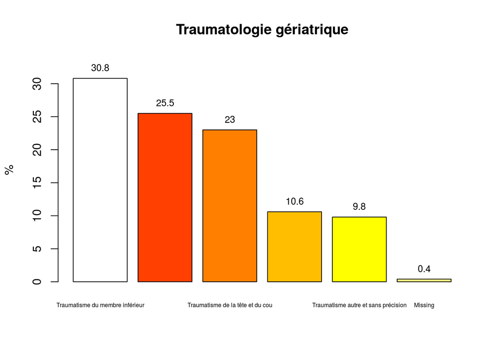

```
## f$data :
##                                      Frequency   %(NA+)   %(NA-)
## Traumatisme du membre inférieur           2627     30.8     30.9
## Traumatisme du membre supérieur           2179     25.5     25.6
## Traumatisme de la tête et du cou          1961     23.0     23.1
## Traumatisme thoraco-abdomino-pelvien       901     10.6     10.6
## Traumatisme autre et sans précision        832      9.8      9.8
## NA's                                        33      0.4      0.0
##   Total                                   8533    100.0    100.0
```

```r
f <- groupe.pathologique(d3g, "trau")
tab1(f$data, cex.names = 0.5, cex = 0.8, sort.group = "decreasing", main = "Traumatologie gériatrique", bar.values = "percent")
```

## Synthèse

Passages bruts:

```
Warning in rbind(s.type.ped, s.type.adl, s.type.ger, s.type): number of
columns of result is not a multiple of vector length (arg 1)
```

[output not shown]

Taux de passage standardisé pour 1000 RPU:

```
Warning in rbind(t1, t2, t3, t4): number of columns of result is not a
multiple of vector length (arg 1)
```

[output not shown]

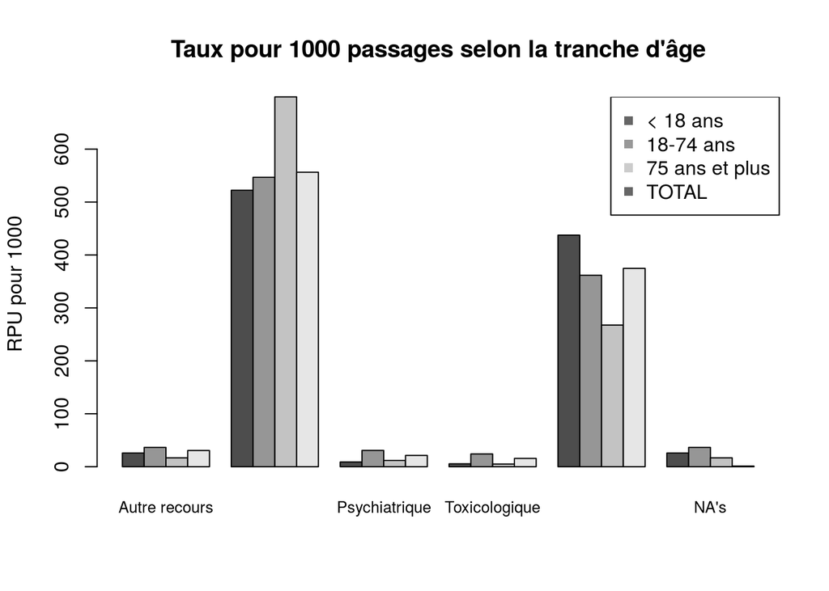

# AVC

```r
AVC<-d3[substr(d3$DP,1,3)>="I60" & substr(d3$DP,1,3)<"I65" | substr(d3$DP,1,3)=="G46" | substr(d3$DP,1,3)=="G45" ,]
AVC$etiologie <- NA
AVC$etiologie[substr(AVC$DP,1,3) %in% c("I60","I61","I62")] <-"HEMO"
AVC$etiologie[substr(AVC$DP,1,3) %in% c("I63","I64")] <-"ISCH"
AVC$etiologie[substr(AVC$DP,1,3) %in% c("I64")] <-"NPRE"
AVC$etiologie[substr(AVC$DP,1,3) %in% c("G45","G46")] <-"AIT"
AVC$etiologie <- as.factor(AVC$etiologie)

n.avc <- nrow(AVC)
```

## RECUEIL DES DONNÉES

- Nombre d’AVC dans l’année (+ rappeler le pourcentage d’exhaustivité du DP par rapport au nombre de RPU): **2476**
- Moyenne quotidienne d’AVC: **6.7835616 AVC/j**
- % d’AVC dans l’activité globale: **0.9319657 %**

## PATIENTS

```
## c.age
##     [0,5)    [5,10)   [10,15)   [15,20)   [20,25)   [25,30)   [30,35)
##         4         5         1         7        20        20        26
##   [35,40)   [40,45)   [45,50)   [50,55)   [55,60)   [60,65)   [65,70)
##        35        50        88       119       148       195       246
##   [70,75)   [75,80)   [80,85)   [85,90)   [90,95)  [95,100) [100,105)
##       222       350       406       338       165        26         5
## [105,110) [110,115) [115,120)
##         0         0         0
```

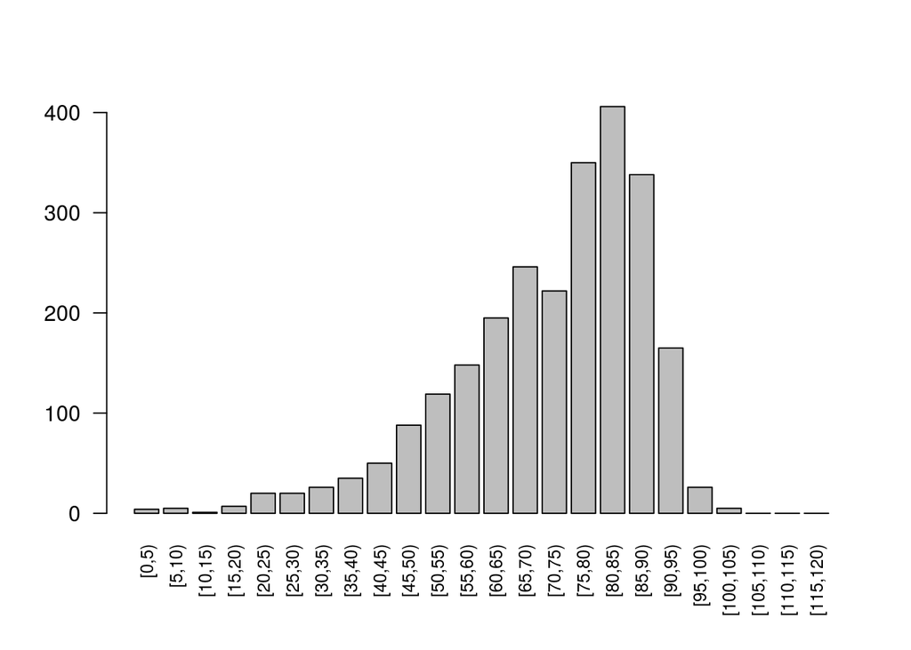

- Sex ratio: 1.027846
- Age moyen: 71.34 ans
- Nombre d’AVC par sous classe d’âge (GT1):

## ARRIVÉE

- Nombre d’AVC et % par tranche d’heure GT1 (matinée, début d’après midi, fin d’après midi, soirée, nuit profonde)

```r
# heures de découpage
p <- c(0, 8, 12, 16, 20, 24)
# légende
np <- c("nuit profonde", "matinée", "début après-midi", "fin après-midi", "soirée")
# extraction des heures à partir du format datetime (http://stackoverflow.com/questions/19292438/split-date-time)
a <- as.numeric(format(as.POSIXct(AVC$ENTREE), "%H"))

x <- cut(a, p, np, right = FALSE)
x2 <- cut(a, p, right = FALSE)

rbind(levels(x2), table(x))
```

```
##      nuit profonde matinée  début après-midi fin après-midi soirée
## [1,] "[0,8)"       "[8,12)" "[12,16)"        "[16,20)"      "[20,24)"
## [2,] "226"         "783"    "778"            "495"          "194"
```

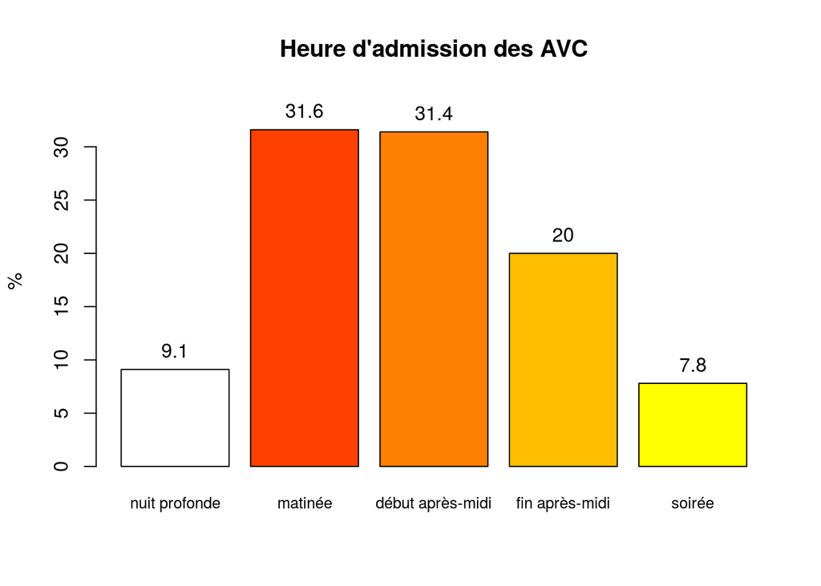

```
## x :
##                  Frequency Percent Cum. percent
## nuit profonde          226     9.1          9.1
## matinée                783    31.6         40.8
## début après-midi       778    31.4         72.2
## fin après-midi         495    20.0         92.2
## soirée                 194     7.8        100.0
##   Total               2476   100.0        100.0
```

```r
tab1(x, cex.names = 0.8, main = "Heure d'admission des AVC", bar.values = "percent", ylab = "%")
```

- % passages en horaire de PDS

## Mode d’arrivée aux urgences

```r
n.avc.moyen <- summary(factor(AVC$TRANSPORT))
n.avc.moyen
```

```
##  AMBU    FO  HELI PERSO  SMUR  VSAB  NA's
##  1152     1    14   543    59   418   289
```

```r
p.avc.moyen <- round(prop.table(n.avc.moyen)*100, 2)
p.avc.moyen
```

```
##  AMBU    FO  HELI PERSO  SMUR  VSAB  NA's
## 46.53  0.04  0.57 21.93  2.38 16.88 11.67
```

- % d’arrivées Moyen perso
- % d’arrivées SMUR
- % d’arrivées VSAV
- % d’arrivées ambulance privée NB : commentaire possible pour expliquer que la somme des 4 pourcentages ci dessus ne fait pas 100 %

## DIAGNOSTIC PRINCIPAL

- Nombre d’AVC et %
- Nombre d’AIT et %
- Nombre de codes “symptomatiques” (hémiplégie, aphasie, amaurose, etc…) et %
- Nombre d’autres hémorragies non traumatiques et %

NB : se référer à l’annexe 4 pour les regroupements.

## DURÉE

- Durée de passage (HORS UHCD) : moyenne et médiane
- % de passages de moins de 4h

## MODE DE SORTIE

- % d’hospitalisation
- % de mutation
- % de transfert
- % de retour à domicile

# Résultats par type d’établissement

La trame commune recueuille les éléments suivants:

[output not shown]

Une table des types

```r
x <- tapply(d3$TYPE_URGENCES, d3$FINESS, table ) # x est un vecteur de list
y <- x[-3] # on retire ste anne qui n'a aucun DP
z <- matrix(unlist(y), nrow = length(y), ncol = 5) # on transforme y en matrice. Pour en faire un data frame: df <- df <- data.frame(matrix(unlist(y), nrow=14, byrow=T),stringsAsFactors=FALSE). Source: http://stackoverflow.com/questions/4227223/r-list-to-data-frame
rownames(z) <- names(x[-3]) # ok
colnames(z) <- names(unlist(x[1])) # ok mais pas terrible
```

# Pathologies en UHTCD

Qui sont les patients hospitalisés en UHTCD ?

```r
dp.uhcd <- d3[d3$ORIENTATION == "UHCD",]
summary(dp.uhcd$TYPE_URGENCES)
```

```
     Autre recours Médico-chirurgical      Psychiatrique
               193              10827                297
     Toxicologique    Traumatologique               NA's
              1344               2924             215041
```

```r
summary(dp.uhcd$CHAPITRE)
```

```
                                     autre et sans précision
                                                           8
               Céphalées, pathologies neurologiques hors SNP
                                                        1637
           Demande de certificats, de dépistage, de conseils
                                                          12
         Dermato-allergologie et atteintes cutanéo-muqueuses
                                                         422
               Difficultés psychosociales, socio-économiques
                                                          40
                Douleurs abdominales, pathologies digestives
                                                        1669
           Douleurs de membre, rhumatologie, orthopédie, SNP
                                                         499
              Douleurs pelviennes, pathologies uro-génitales
                                                         817
        Douleurs thoraciques, pathologies cardio-vasculaires
                                                        1306
       Dyspnées, pathologies des voies aériennes inférieures
                                                        1718
                            Fièvre et infectiologie générale
                                                         403
            Iatrogénie et complication post chirurgicale SAI
                                                          92
                                     Intoxication alcoolique
                                                         584
                         Intoxication au monoxyde de carbone
                                                          11
                                 Intoxication médicamenteuse
                                                         656
                        Intoxication par d'autres substances
                                                          93
Malaises, lipothymies, syncopes, étourdissements et vertiges
                                                         721
           ORL, ophtalmo, stomato et carrefour aéro-digestif
                                                         163
     Recours lié à l'organisation de la continuité des soins
                                                          34
                     Réorientations, fugues,  refus de soins
                                                           2
                       Signes généraux et autres pathologies
                                                        1472
               Soins de contrôle, surveillances et entretien
                                                           5
                         Traumatisme autre et sans précision
                                                         416
                            Traumatisme de la tête et du cou
                                                         748
                             Traumatisme du membre inférieur
                                                         140
                             Traumatisme du membre supérieur
                                                        1326
                        Traumatisme thoraco-abdomino-pelvien
                                                         294
           Troubles du psychisme, pathologies psychiatriques
                                                         297
                                                        NA's
                                                      215041
```

```r
# nombre de DP non renseignés
n.rens.uhcd <- sum(!is.na(dp.uhcd$CHAPITRE))
# top 10
s.dp.chap.uhcd <- round(sort(summary(dp.uhcd$CHAPITRE[!is.na(dp.uhcd$CHAPITRE)])*100/n.rens.uhcd, decreasing = TRUE),2)
head(s.dp.chap.uhcd, 10)
```

```
       Dyspnées, pathologies des voies aériennes inférieures
                                                       11.02
                Douleurs abdominales, pathologies digestives
                                                       10.71
               Céphalées, pathologies neurologiques hors SNP
                                                       10.50
                       Signes généraux et autres pathologies
                                                        9.44
                             Traumatisme du membre supérieur
                                                        8.51
        Douleurs thoraciques, pathologies cardio-vasculaires
                                                        8.38
              Douleurs pelviennes, pathologies uro-génitales
                                                        5.24
                            Traumatisme de la tête et du cou
                                                        4.80
Malaises, lipothymies, syncopes, étourdissements et vertiges
                                                        4.63
                                 Intoxication médicamenteuse
                                                        4.21
```